# **CNNs - Malaria image recogenization problem** Universitat Politècnica de Catalunya

Geraldo Gariza, Jan Leyva and Andreu Meca

7 de junio, 2021

```r
# reticulate::py_install("pillow")
# use_python("/Library/Frameworks/Python.framework/Versions/3.9/bin/python3")
# use_python("~/local/bin/python3")
```

# Introduction

Malaria is a deadly, infectious mosquito-borne disease caused by Plasmodium parasites. These parasites are transmitted by the bites of infected female Anopheles mosquitoes. With regular manual diagnosis of blood smears, it is an intensive manual process requiring proper expertise in classifying and counting the parasitized and uninfected cells. Typically this may not scale well and might cause problems if we do not have the right expertise in specific regions around the world. We are lucky to have researchers at the Lister Hill National Center for Biomedical Communications (LHNCBC), part of National Library of Medicine (NLM) who have carefully collected and annotated this dataset of healthy and infected blood smear images. There is a balanced dataset of 13779 malaria and non-malaria (uninfected) cell images. The dataset consist of near thousand images downloaded from the official website that have been resized (64x64x3). The images are organized in three folders: train, validation and test. Deep Learning models, or to be more specific, Convolutional Neural Networks (CNNs) have proven to be really effective in a wide variety of computer vision tasks..

The first step is to charge the directories where the data is stored, which is inside three folders called `train`, `test` and `validation`

Once the data is loaded, it is resized into a generator object.

```r
# image_data_generator Generate batches of image data with real-time data augmentation. The data will be looped over (in batches).
train_datagen <- image_data_generator(rescale = 1/255) #
validation_datagen <- image_data_generator(rescale = 1/255) #
test_datagen <- image_data_generator(rescale = 1/255) #

#flow_images_from_directory Generates batches of data from images in a directory (with optional augmented/normalized data)
train_generator <- flow_images_from_directory(
train_dir,
train_datagen,
target_size = c(64, 64),
batch_size = 1,
class_mode = "binary"
)
validation_generator <- flow_images_from_directory(
validation_dir,
validation_datagen,
target_size = c(64, 64),
batch_size = 1,
class_mode = "binary"
)


test_datagen <- image_data_generator(rescale = 1/255) #

test_generator <- flow_images_from_directory(
test_dir,
test_datagen,
target_size = c(64, 64),
batch_size = 1,
class_mode = "binary"
)
batch <- generator_next(train_generator)
str(batch)
```

```
## List of 2
##  $ : num [1, 1:64, 1:64, 1:3] 0 0 0 0 0 0 0 0 0 0 ...
##  $ : num [1(1d)] 0
```

Now, we have loaded 1001 images for train, 420 for validation and 514 to test all with two classes. Also all are of dimension 64x64x3 and, in case that one of the images is not of this exact size, the generator will reshape it to match the correct dimension.

# Section 1 - CNN

## Implement a CNN according with the summary in Figure 1

```r
model <- keras_model_sequential() %>%
  layer_conv_2d(filters = 32, kernel_size = c(3, 3), activation = "relu",
                input_shape = c(64, 64, 3)) %>%
  layer_max_pooling_2d(pool_size = c(2, 2)) %>%
  layer_conv_2d(filters = 64, kernel_size = c(3, 3), activation = "relu") %>%
  layer_max_pooling_2d(pool_size = c(2, 2)) %>%
  layer_conv_2d(filters = 128, kernel_size = c(3, 3), activation = "relu") %>%
  layer_max_pooling_2d(pool_size = c(2, 2)) %>%
  layer_conv_2d(filters = 128, kernel_size = c(3, 3), activation = "relu") %>%
  layer_max_pooling_2d(pool_size = c(2, 2)) %>%
  layer_flatten() %>%
  layer_dense(units = 512, activation = "relu") %>%
  layer_dense(units = 1, activation = "sigmoid")
```

```r
summary(model)
```

```
## Model: "sequential"
## ________________________________________________________________________________
## Layer (type)                        Output Shape                    Param #
## ================================================================================
## conv2d_3 (Conv2D)                   (None, 62, 62, 32)              896
## ________________________________________________________________________________
## max_pooling2d_3 (MaxPooling2D)      (None, 31, 31, 32)              0
## ________________________________________________________________________________
## conv2d_2 (Conv2D)                   (None, 29, 29, 64)              18496
## ________________________________________________________________________________
## max_pooling2d_2 (MaxPooling2D)      (None, 14, 14, 64)              0
## ________________________________________________________________________________
## conv2d_1 (Conv2D)                   (None, 12, 12, 128)             73856
## ________________________________________________________________________________
## max_pooling2d_1 (MaxPooling2D)      (None, 6, 6, 128)               0
## ________________________________________________________________________________
## conv2d (Conv2D)                     (None, 4, 4, 128)               147584
## ________________________________________________________________________________
## max_pooling2d (MaxPooling2D)        (None, 2, 2, 128)               0
## ________________________________________________________________________________
## flatten (Flatten)                   (None, 512)                     0
## ________________________________________________________________________________
## dense_1 (Dense)                     (None, 512)                     262656
## ________________________________________________________________________________
## dense (Dense)                       (None, 1)                       513
## ================================================================================
## Total params: 504,001
## Trainable params: 504,001
## Non-trainable params: 0
## ________________________________________________________________________________
```

# Section 2 - CNN definition

## Define conveniently the model (optimization, loss, metric, …)

Binary Cross-Entropy $= -\frac{1}{N}\sum_{i = 1}^{N}{(y_ilog(p(y_i))+(1-y_i)log(1-p(y_i))}$

This is the chosen loss function as the aim of this CNN is predict two categories (malaria or not malaria)

```r
model %>% compile(
  loss = "binary_crossentropy",
  optimizer = optimizer_rmsprop(lr = 1e-4),
  metrics = c("accuracy")
)
```

```r
history <- model %>% fit_generator(
  train_generator,
  steps_per_epoch = 1000,
  epochs = 30,
  validation_data = validation_generator,
  validation_steps = 50
)
```

In order to visualize the model performance a plot of the performance for each epoch of the CNN is generated

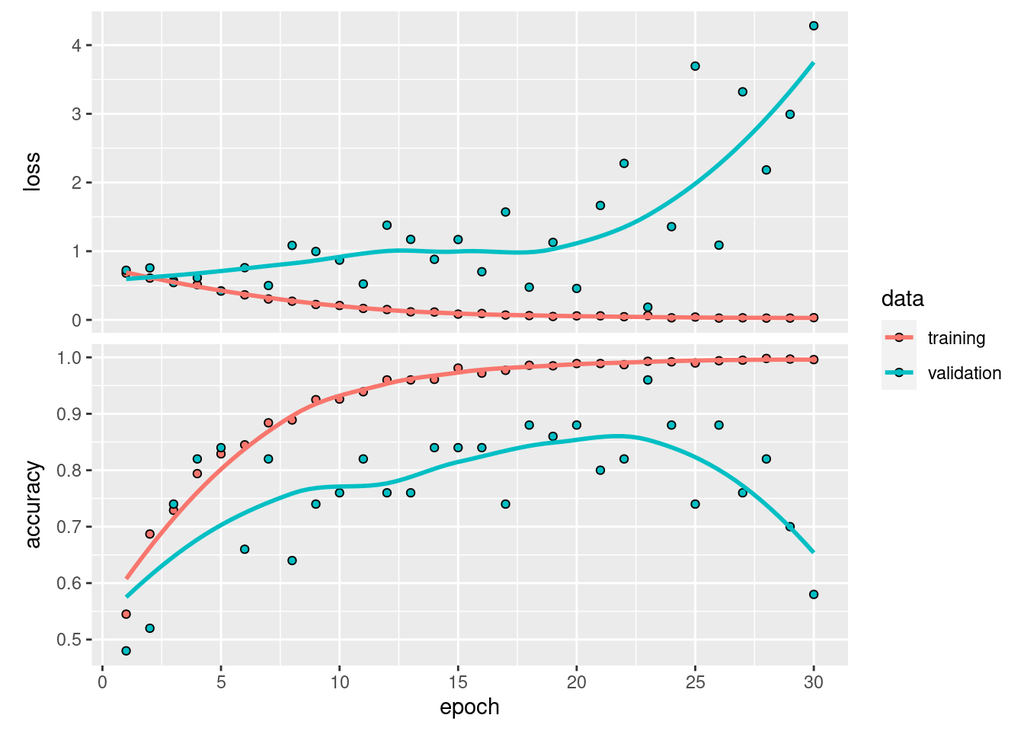

```r
plot(history)
```

To save the model we use the save_model_hdf5 and to load a model the load_model_hdf5

```r
model %>% save_model_hdf5("cnn.h5")
```

```r
# model_load <- load_model_hdf5("cnn.h5")
```

# Section 3 - Tunning the hyperparameter

## Using tfruns package tune the hyperparameter batch_size exploring the grid c(16, 32, 64)

In this section the hyperparameter `batch_size` is tuned to explore the c(16, 32, 64) grid using the function flags() to set the flag hyperparameter

```r
FLAGS <- flags(
   flag_string("hl1", "batch size"))
```

In the next chunk the model is re-defined to introduce the flags in order to tune the hyperparameter

```r
model %>% fit(train_generator, train_generator$labels, epochs = 10,
               batch_size = FLAGS$hl1)
```

Training the model that is stored in `cnn_assignment.R` with the different `batch size` in a loop.

```r
for (hl1 in c(16, 32, 64)){
training_run("cnn_assignment.R", flags = c(hl1 = hl1))
}
```

```
## Using run directory runs/2021-06-07T20-17-50Z
```

[output not shown]

[output cut: 31 more lines]

```
##
## > history <- model %>% fit(train_generator, epochs = 10,
## +     validation_data = validation_generator, batch_size = FLAGS$hl1)
##
## > model %>% evaluate(validation_generator, validation_generator$labels)
##      loss  accuracy
## 0.5922654 0.6761905
##
## > y_pred <- model %>% predict(validation_generator)
##
## > y_pred_ <- c()
##
## > for (i in 1:length(y_pred)) {
## +     ifelse(y_pred[i] > 0.50001, y_pred_[i] <- 1, y_pred_[i] <- 0)
## + }
```

```
##
## Run completed: runs/2021-06-07T20-17-50Z
```

```
## Using run directory runs/2021-06-07T20-18-19Z
```

[output not shown]

[output cut: 31 more lines]

```
##
## > history <- model %>% fit(train_generator, epochs = 10,
## +     validation_data = validation_generator, batch_size = FLAGS$hl1)
##
## > model %>% evaluate(validation_generator, validation_generator$labels)
##      loss  accuracy
## 0.6215063 0.6928571
##
## > y_pred <- model %>% predict(validation_generator)
##
## > y_pred_ <- c()
##
## > for (i in 1:length(y_pred)) {
## +     ifelse(y_pred[i] > 0.50001, y_pred_[i] <- 1, y_pred_[i] <- 0)
## + }
```

```
##
## Run completed: runs/2021-06-07T20-18-19Z
```

```
## Using run directory runs/2021-06-07T20-18-43Z
```

[output not shown]

[output cut: 31 more lines]

```
##
## > history <- model %>% fit(train_generator, epochs = 10,
## +     validation_data = validation_generator, batch_size = FLAGS$hl1)
##
## > model %>% evaluate(validation_generator, validation_generator$labels)
##      loss  accuracy
## 0.6022744 0.7000000
##
## > y_pred <- model %>% predict(validation_generator)
##
## > y_pred_ <- c()
##
## > for (i in 1:length(y_pred)) {
## +     ifelse(y_pred[i] > 0.50001, y_pred_[i] <- 1, y_pred_[i] <- 0)
## + }
```

```
##
## Run completed: runs/2021-06-07T20-18-43Z
```

If we want see the performance of the runs that we did before:

```r
View(ls_runs())
```

In order to compare the last two models:

```r
compare_runs()
```

# Section 4 - Early-stopping callbacks()

# Section 5 - Predict

## Assess the performance of the CNN predicting the categories of test images and obtain the confusion matrix

```r
# evaluate
scores <- model %>% evaluate(test_generator,
                             test_generator$labels,
                             verbose = 0)

# Output metrics
cat('Test loss:', scores[[1]], '\n')
```

```
## Test loss: 1.527599
```

```r
cat('Test accuracy:', scores[[2]], '\n')
```

```
## Test accuracy: 0.6750973
```

As we did before with the training and validation sets, the vector containing the test images is loaded into a new object where the test data is reshaped to have a 64x64x3 dimension

```r
y_pred <-model %>%
            predict(test_generator)

y_pred_ <- c()
for(i in 1:length(y_pred)){
  ifelse(y_pred[i] > 0.50001, y_pred_[i] <- 1, y_pred_[i] <- 0)
}

confusionMatrix(as.factor(y_pred_), as.factor(test_generator$labels))
```

```
## Confusion Matrix and Statistics
##
##           Reference
## Prediction   0   1
##          0 223 193
##          1  44  54
##
##                Accuracy : 0.5389
##                  95% CI : (0.4947, 0.5826)
##     No Information Rate : 0.5195
##     P-Value [Acc > NIR] : 0.2009
##
##                   Kappa : 0.0551
##
##  Mcnemar's Test P-Value : <2e-16
##
##             Sensitivity : 0.8352
##             Specificity : 0.2186
##          Pos Pred Value : 0.5361
##          Neg Pred Value : 0.5510
##              Prevalence : 0.5195
##          Detection Rate : 0.4339
##    Detection Prevalence : 0.8093
##       Balanced Accuracy : 0.5269
##
##        'Positive' Class : 0
##
```

This confusion is not correct, we detected diferences using predict with the generator and the `evaluate` function used before. For this reason we try to import the images and store it in array of dimension (514, 64, 64, 3). As we have now the images in array instead of a generator we can use the function `predict_classes` that return the class predicted by CNN. This time the confusion matrix return the same result that we obtaint before with `evaluate`.

```r
fnames_inf   <- list.files(test_dir_infected, full.names = TRUE)
fnames_uninf <- list.files(test_dir_uninfected, full.names = TRUE)
files_names  <-c(fnames_inf, fnames_uninf)

img_array <- array(dim = c(length(files_names),64,64,3)) # dimension of the array including images
for(i in 1:length(files_names)){
  img<-image_load(files_names[i])
  img_tensor<-image_to_array(img)
  img_tensor<-array_reshape(img_tensor,c(1,64,64,3))
  img_array[i,,,]<-img_tensor/255
}
dim(img_array)
```

```
## [1] 514  64  64   3
```

```r
test_labels<-as.factor(c( rep(0, length(fnames_inf)), rep(1, length(fnames_uninf)) ))
head(test_labels)
```

```
## [1] 0 0 0 0 0 0
## Levels: 0 1
```

```r
predict_test <- model %>%
                      predict_classes(img_array)
```

Keras doesn’t include a built-in Confusion Matrix, therefore the `caret` package is loaded to make use of the `confusionMatrix` function. First of all, we transform the probabilities greater than 0.5 to class 1, else to 0. We did this because the image object is a generator and the function `predict_classes` does not accept generators, only vectors list or atomics.

```r
confusionMatrix(as.factor(predict_test), test_labels)
```

```
## Confusion Matrix and Statistics
##
##           Reference
## Prediction   0   1
##          0 258 158
##          1   9  89
##
##                Accuracy : 0.6751
##                  95% CI : (0.6327, 0.7155)
##     No Information Rate : 0.5195
##     P-Value [Acc > NIR] : 6.023e-13
##
##                   Kappa : 0.3342
##
##  Mcnemar's Test P-Value : < 2.2e-16
##
##             Sensitivity : 0.9663
##             Specificity : 0.3603
##          Pos Pred Value : 0.6202
##          Neg Pred Value : 0.9082
##              Prevalence : 0.5195
##          Detection Rate : 0.5019
##    Detection Prevalence : 0.8093
##       Balanced Accuracy : 0.6633
##
##        'Positive' Class : 0
##
```

For futures works, it would be interesting to apply different techniques to mitigate the overfitting such as dropout, regularization technique used to change the node architecture in every iteration, weight decay which is also called L2 regularization, technique that introduces a penalization parameter, or use data augmentation to increase the variety of data used in the model training step.

# Section 6 - Convolutional AutoEncoder (CAE)

## Implement two Convolutional AutoEncoder (CAE). The first with 3 nodes in z layer (or bottleneck), the second with 10 nodes in z layer. Feel free to choose the number of convolutional layers, filter sizes, number of filters:

An autoencoder is a neural network designed to learn a representation of a set of data and ignore the signal noise. It has an encoder and a decoder part, the first one to reduce the dimension of the data and the second one to reconstruct the input as well as possible.

First of all, we import the images again but this time with the `class_mode = input`. This is really important in order to get a results with sens. This solutions is found in the following discussion [link](https://stackoverflow.com/questions/51669382/keras-dimension-mismatch-in-last-layer-of-autoencoder/51673998#51673998).

Let’s build the first Convolutional Autoencoder, which it only has the requirement of having 3 nodes in layer z.

### Convolutional Encoder

```r
input_dim <- c(64, 64, 3)
model_enc <- keras_model_sequential()
model_enc %>%
  layer_conv_2d(filters = 3, kernel_size = c(3,3),
                activation = "relu", padding = "same",
                input_shape = input_dim)  %>%
  layer_max_pooling_2d(pool_size = c(4,4), padding = "same")  %>%
  layer_conv_2d(filters = 12, kernel_size = c(3,3),
                activation = "relu", padding = "same") %>%
  layer_max_pooling_2d(pool_size = c(3,3), padding = "same")  %>%
  layer_conv_2d(filters = 24, kernel_size = c(3,3),
                activation = "relu", padding = "same")%>%
  layer_max_pooling_2d(pool_size = c(2,2), padding = "same")  %>%
  layer_conv_2d(filters = 3, kernel_size = c(3,3),
                activation = "relu", padding = "same")

summary(model_enc)
```

```
## Model: "sequential"
## ________________________________________________________________________________
## Layer (type)                        Output Shape                    Param #
## ================================================================================
## conv2d_3 (Conv2D)                   (None, 64, 64, 3)               84
## ________________________________________________________________________________
## max_pooling2d_2 (MaxPooling2D)      (None, 16, 16, 3)               0
## ________________________________________________________________________________
## conv2d_2 (Conv2D)                   (None, 16, 16, 12)              336
## ________________________________________________________________________________
## max_pooling2d_1 (MaxPooling2D)      (None, 6, 6, 12)                0
## ________________________________________________________________________________
## conv2d_1 (Conv2D)                   (None, 6, 6, 24)                2616
## ________________________________________________________________________________
## max_pooling2d (MaxPooling2D)        (None, 3, 3, 24)                0
## ________________________________________________________________________________
## conv2d (Conv2D)                     (None, 3, 3, 3)                 651
## ================================================================================
## Total params: 3,687
## Trainable params: 3,687
## Non-trainable params: 0
## ________________________________________________________________________________
```

The Convolutional Decoder is built with a structure of 5 convolutional layers, the first four with the ReLU function and the last one with a sigmoid activation function. The inputs of the decoder have a dimension of 3x3x3 and the output, as in the input of the decoder, a dimension of 64x64x3.

### Convolutional Decoder

```r
model_dec <- keras_model_sequential()
model_dec %>%
  layer_conv_2d(filters = 3, kernel_size = c(3,3),
                activation = "relu", padding = "same",
                input_shape =c(3,3, 3) )  %>%
  layer_upsampling_2d(size = c(2,2))%>%
  layer_conv_2d(24,kernel_size = c(3,3), activation = "relu",padding = "same")%>%
  layer_upsampling_2d(size =  c(2,2))%>%
  layer_conv_2d(48, kernel_size =c(3,3), activation = "relu")%>%
  layer_upsampling_2d(size =  c(2,2))%>%
  layer_conv_2d(24, kernel_size =c(3,3), activation = "relu" )%>%
  layer_conv_2d(3, kernel_size =c(3,3), activation = "sigmoid" )%>%
  layer_upsampling_2d(size =  c(4,4))

summary(model_dec)
```

```
## Model: "sequential_1"
## ________________________________________________________________________________
## Layer (type)                        Output Shape                    Param #
## ================================================================================
## conv2d_8 (Conv2D)                   (None, 3, 3, 3)                 84
## ________________________________________________________________________________
## up_sampling2d_3 (UpSampling2D)      (None, 6, 6, 3)                 0
## ________________________________________________________________________________
## conv2d_7 (Conv2D)                   (None, 6, 6, 24)                672
## ________________________________________________________________________________
## up_sampling2d_2 (UpSampling2D)      (None, 12, 12, 24)              0
## ________________________________________________________________________________
## conv2d_6 (Conv2D)                   (None, 10, 10, 48)              10416
## ________________________________________________________________________________
## up_sampling2d_1 (UpSampling2D)      (None, 20, 20, 48)              0
## ________________________________________________________________________________
## conv2d_5 (Conv2D)                   (None, 18, 18, 24)              10392
## ________________________________________________________________________________
## conv2d_4 (Conv2D)                   (None, 16, 16, 3)               651
## ________________________________________________________________________________
## up_sampling2d (UpSampling2D)        (None, 64, 64, 3)               0
## ================================================================================
## Total params: 22,215
## Trainable params: 22,215
## Non-trainable params: 0
## ________________________________________________________________________________
```

The loss function chosen is the binary cross-entropy, the same that was used for the Convolutional Neural Network in Section 2, but now the optimizer is adam and the metric is the mean squared error.

```r
CAE<-keras_model_sequential()
CAE %>%model_enc%>%model_dec
```

```
## Model
## Model: "sequential_2"
## ________________________________________________________________________________
## Layer (type)                        Output Shape                    Param #
## ================================================================================
## sequential (Sequential)             (None, 3, 3, 3)                 3687
## ________________________________________________________________________________
## sequential_1 (Sequential)           (None, 64, 64, 3)               22215
## ================================================================================
## Total params: 25,902
## Trainable params: 25,902
## Non-trainable params: 0
## ________________________________________________________________________________
```

```r
summary(CAE)
```

```
## Model: "sequential_2"
## ________________________________________________________________________________
## Layer (type)                        Output Shape                    Param #
## ================================================================================
## sequential (Sequential)             (None, 3, 3, 3)                 3687
## ________________________________________________________________________________
## sequential_1 (Sequential)           (None, 64, 64, 3)               22215
## ================================================================================
## Total params: 25,902
## Trainable params: 25,902
## Non-trainable params: 0
## ________________________________________________________________________________
```

```r
CAE %>% compile(
  loss = "binary_crossentropy",
  #optimizer = optimizer_rmsprop(),
  optimizer = "adam",
  metrics = c("mean_squared_error")
)
```

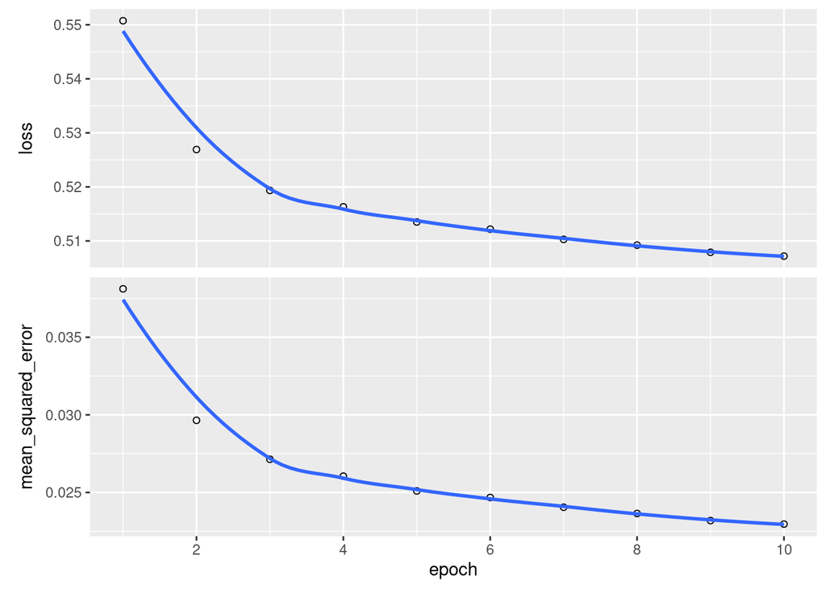

```r
history <- CAE %>% fit(
  x= train_generator , y = train_generator ,   # Autoencoder
  epochs = 10,
  suffle = TRUE
  #validation_data = validation_generator
)

plot(history)
```

- Plot original images Let’s plot the original image and compare the input and the output of the Autoencoder so that we can see the differences

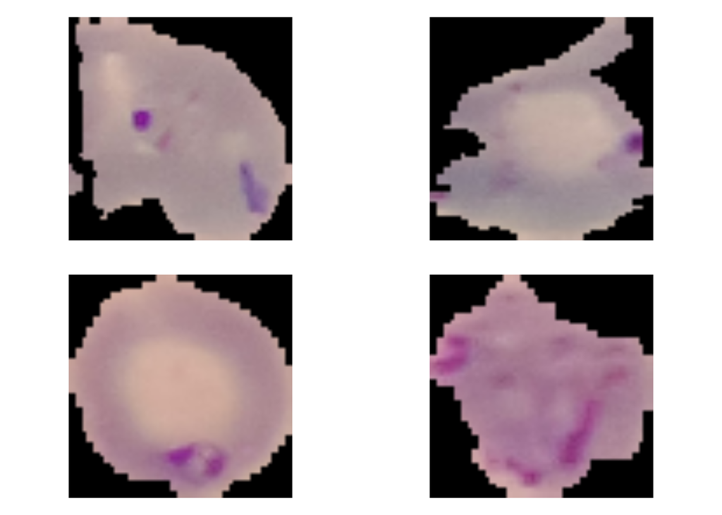

```r
op <- par(mfrow = c(2, 2), pty = "s", mar = c(1, 0, 1, 0))
for (i in 1:4){
plot(as.raster(img_array[i,,,]))
}
```

- Predict and plot image from CAE output

Now, the prediction of the CAE is computed with the function `predict()`

```r
output_cifra<-predict(CAE, test_generator)
dim(output_cifra)
```

```
## [1] 514  64  64   3
```

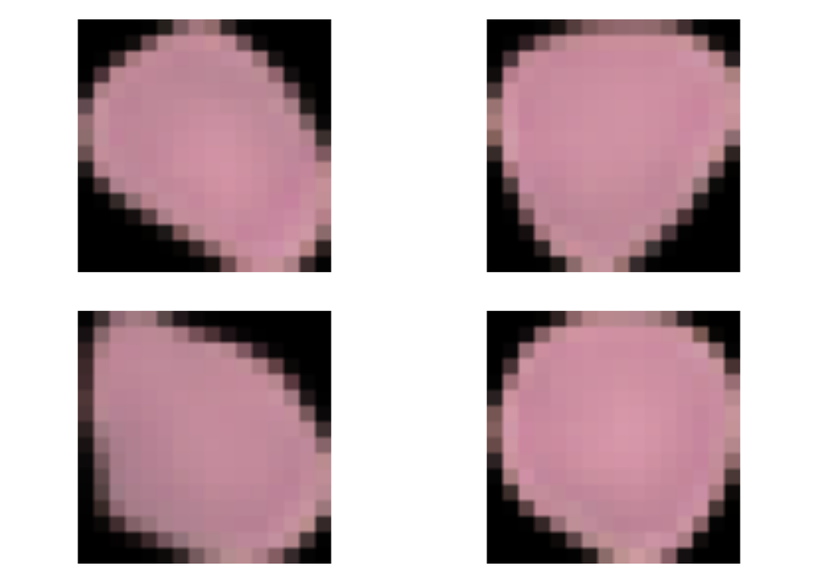

```r
op <- par(mfrow = c(2, 2), pty = "s", mar = c(1, 0, 1, 0))
for (i in 1:4){
plot(as.raster((output_cifra[i,,,])))
}
```

- In gray scale

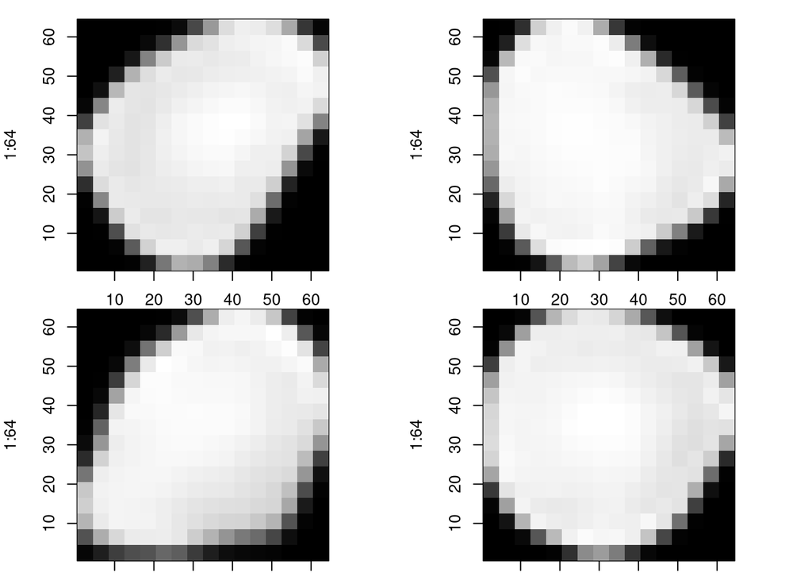

```r
op <- par(mfrow = c(2, 2), pty = "s", mar = c(1, 0, 1, 0))
for (i in 1:4){
im<-matrix(output_cifra[i,,,1], nrow=64, ncol=64)
image(1:64, 1:64, im, col=gray((0:255)/255))
}
```

- Plot images from encoder output

```r
enc_output_cifra<-predict(model_enc, train_generator)
dim(enc_output_cifra)
```

```
## [1] 1001    3    3    3
```

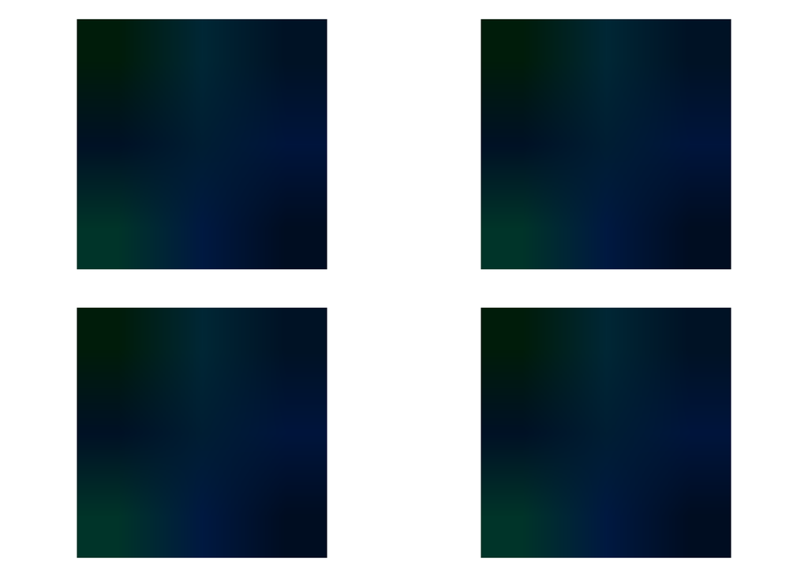

```r
op <- par(mfrow = c(2, 2), pty = "s", mar = c(1, 0, 1, 0))
for (i in 1:4){
plot(as.raster(enc_output_cifra[1,,,]/10))
}
```

- From encoder to decoder

```r
dec_output_cifra<-predict(model_dec, enc_output_cifra)
dim(dec_output_cifra)
```

```
## [1] 1001   64   64    3
```

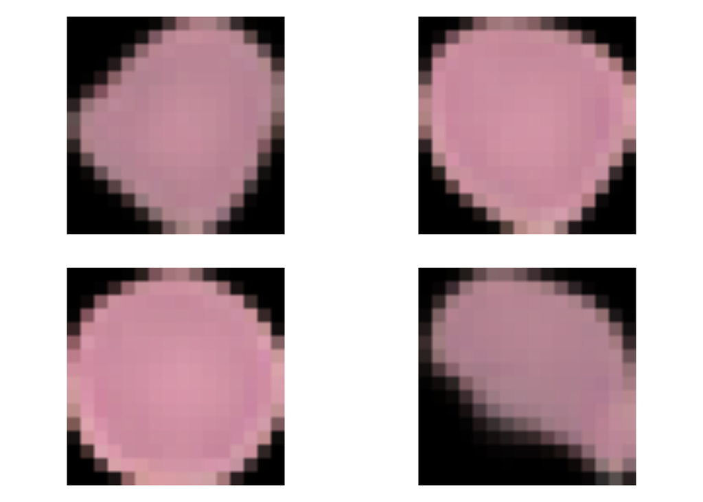

```r
op <- par(mfrow = c(2, 2), pty = "s", mar = c(1, 0, 1, 0))
for (i in 1:4){
plot(as.raster(dec_output_cifra[i,,,]))
}
```

### Convolutional AutoEncoder z = 10

Now, it’s time for the second Convolutional AutoEncoder, with the requirement to have 10 nodes in the z layer.

- CAE encoder size 10

```r
#### Convolutional Encoder
model_enc10 <- keras_model_sequential()
model_enc10 %>%
  layer_conv_2d(filters = 12, kernel_size = c(3,3),
                activation = "relu", padding = "same",
                input_shape = input_dim)  %>%
  layer_max_pooling_2d(pool_size = c(2,2), padding = "same")  %>%
  layer_conv_2d(filters = 8, kernel_size = c(3,3),
                activation = "relu") %>%
  layer_max_pooling_2d(pool_size = c(3,3), padding = "same")  %>%
  layer_conv_2d(filters = 3, kernel_size = c(3,3),
                activation = "relu", padding = "same")

summary(model_enc10)
```

```
## Model: "sequential_3"
## ________________________________________________________________________________
## Layer (type)                        Output Shape                    Param #
## ================================================================================
## conv2d_11 (Conv2D)                  (None, 64, 64, 12)              336
## ________________________________________________________________________________
## max_pooling2d_4 (MaxPooling2D)      (None, 32, 32, 12)              0
## ________________________________________________________________________________
## conv2d_10 (Conv2D)                  (None, 30, 30, 8)               872
## ________________________________________________________________________________
## max_pooling2d_3 (MaxPooling2D)      (None, 10, 10, 8)               0
## ________________________________________________________________________________
## conv2d_9 (Conv2D)                   (None, 10, 10, 3)               219
## ================================================================================
## Total params: 1,427
## Trainable params: 1,427
## Non-trainable params: 0
## ________________________________________________________________________________
```

The Convolutional Decoder is built with a structure of 3 convolutional layers, the first two with the ReLU function and the last one, as we did before, with a sigmoid activation function. The inputs of the decoder have a dimension of 10x10x3 and the output, as in the input of the decoder, a dimension of 64x64x3

- CAE decoder size 10

```r
model_dec10 <- keras_model_sequential()
model_dec10 %>%
  layer_conv_2d(filters = 3, kernel_size = c(3,3),
                activation = "relu", padding = "same",
                input_shape =c(10,10,3) )  %>%
  layer_upsampling_2d(size = c(2,2)) %>%
  layer_conv_2d(filters = 4, kernel_size = c(3,3),
                activation = "relu")%>%
  layer_conv_2d(filters = 3, kernel_size = c(3,3),
                activation = "sigmoid")%>%
  layer_upsampling_2d(size = c(4,4)) %>%


summary(model_dec10)
```

```
## Model: "sequential_4"
## ________________________________________________________________________________
## Layer (type)                        Output Shape                    Param #
## ================================================================================
## conv2d_14 (Conv2D)                  (None, 10, 10, 3)               84
## ________________________________________________________________________________
## up_sampling2d_5 (UpSampling2D)      (None, 20, 20, 3)               0
## ________________________________________________________________________________
## conv2d_13 (Conv2D)                  (None, 18, 18, 4)               112
## ________________________________________________________________________________
## conv2d_12 (Conv2D)                  (None, 16, 16, 3)               111
## ________________________________________________________________________________
## up_sampling2d_4 (UpSampling2D)      (None, 64, 64, 3)               0
## ================================================================================
## Total params: 307
## Trainable params: 307
## Non-trainable params: 0
## ________________________________________________________________________________
```

- Join the encoder and decoder models

```r
model10<-keras_model_sequential()
model10 %>% model_enc10 %>%model_dec10
```

```
## Model
## Model: "sequential_5"
## ________________________________________________________________________________
## Layer (type)                        Output Shape                    Param #
## ================================================================================
## sequential_3 (Sequential)           (None, 10, 10, 3)               1427
## ________________________________________________________________________________
## sequential_4 (Sequential)           (None, 64, 64, 3)               307
## ================================================================================
## Total params: 1,734
## Trainable params: 1,734
## Non-trainable params: 0
## ________________________________________________________________________________
```

```r
model10 %>% compile(
  loss = "mean_squared_error",
  #optimizer = optimizer_rmsprop(),
  optimizer = "adam",
  metrics = c("mean_squared_error")
)

history <- model10 %>% fit(
  x=train_generator , y =train_generator,   # Autoencoder
  epochs = 5,
  suffle = TRUE
#  validation_data = list(x_test_cifra,x_test_cifra)
)
```

### Prediction of CAE (size 10)

- Plot output CAE 10

```r
output_cifra_10 <-predict(model10, test_generator)
dim(output_cifra_10)
```

```
## [1] 514  64  64   3
```

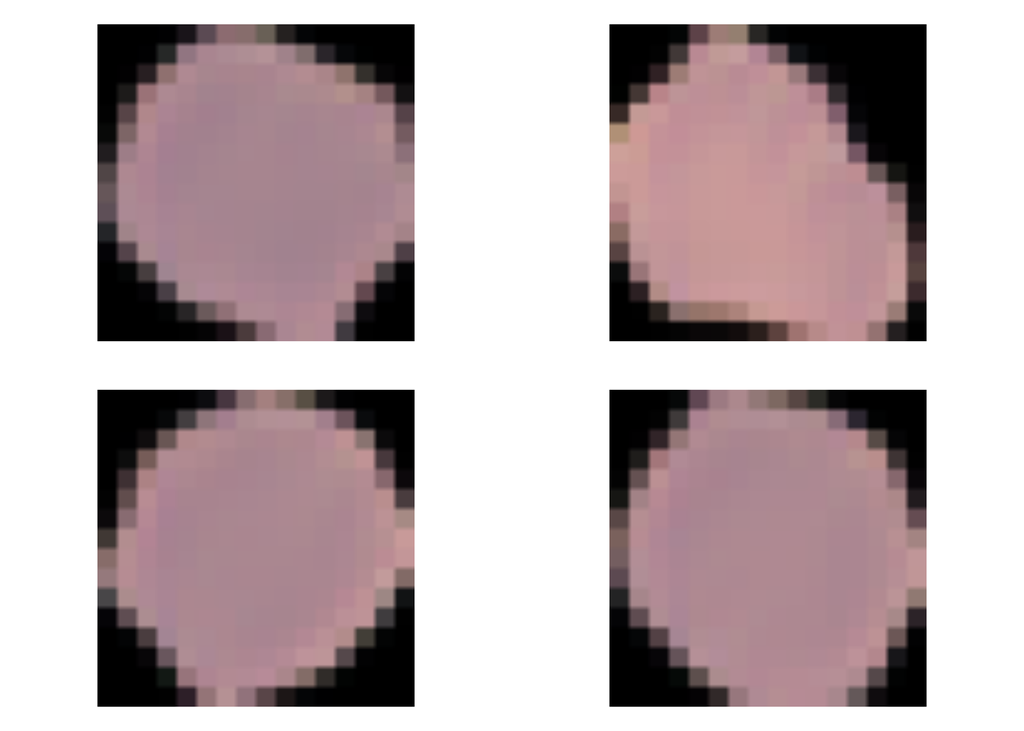

```r
op <- par(mfrow = c(2, 2), pty = "s", mar = c(1, 0, 1, 0))
for (i in 1:4){
plot(as.raster(output_cifra_10[i,,,]))
}
```

```r
enc_output_cifra_10 <-predict(model_enc, test_generator)
dim(enc_output_cifra_10)
```

```
## [1] 514   3   3   3
```

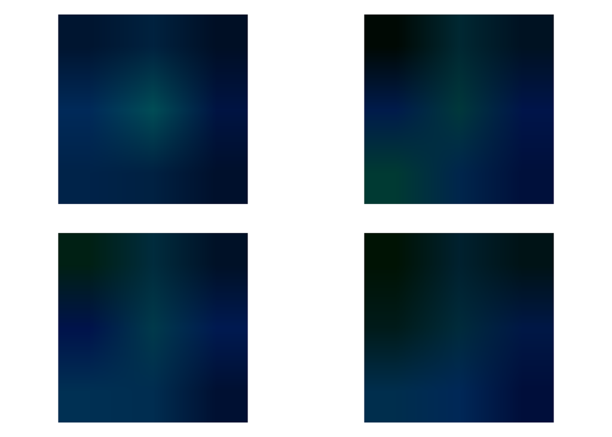

```r
op <- par(mfrow = c(2, 2), pty = "s", mar = c(1, 0, 1, 0))
for (i in 1:4){
plot(as.raster(enc_output_cifra_10[i,,,]/10))
}
```

```r
dec_output_cifra_10 <-predict(model_dec, enc_output_cifra_10)
dim(dec_output_cifra_10)
```

```
## [1] 514  64  64   3
```

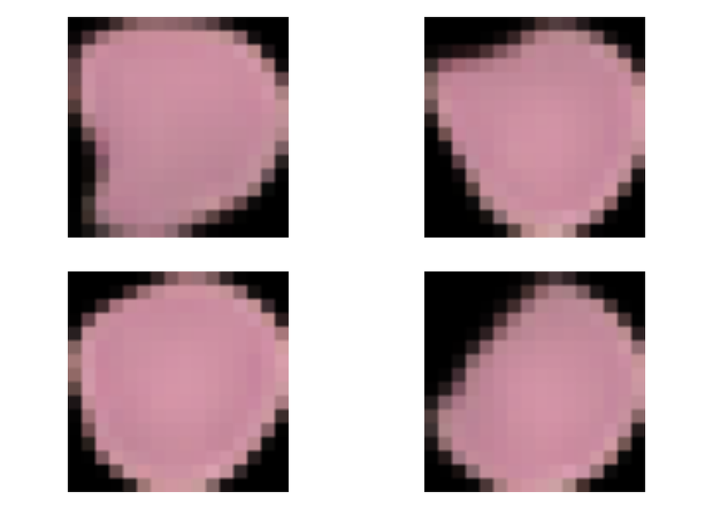

```r
op <- par(mfrow = c(2, 2), pty = "s", mar = c(1, 0, 1, 0))
for (i in 1:4){
plot(as.raster(dec_output_cifra_10[i,,,]))
}
```

# Section 7

## Represent graphically the results from images test to show the association between z layer activations and the class images. Compare the representations displayed by both CAE architectures

Let’s plot the output of both AutoEncoders to check if there are any differences the naked eye is able to see

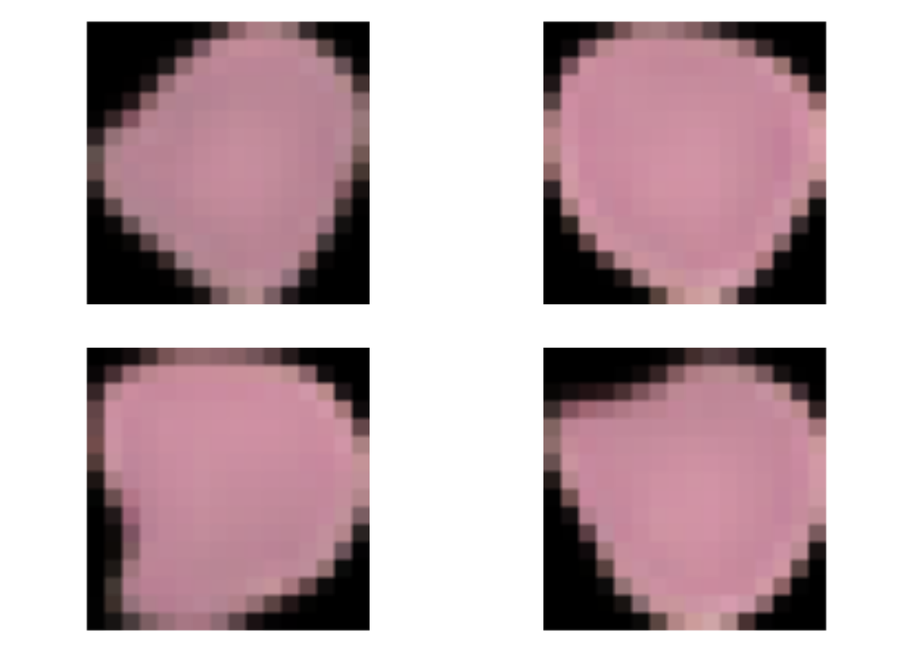

```r
op <- par(mfrow = c(2, 2), pty = "s", mar = c(1, 0, 1, 0))
for (i in 1:2){
plot(as.raster(dec_output_cifra[i,,,]), main = "CAE z = 3")
}
for (i in 1:2){
plot(as.raster(dec_output_cifra_10[i,,,]), main = "CAE z = 10")
}
```